# Lending Club Data Analysis

Chengdong Liang

November 2, 2016

## Data overview

After loading the entire data set I would like to check its structure and summarise it.

```r
# print dimentions
dim(loanbook)
```

```
## [1] 887379     77
```

```r
#print column names
colnames(loanbook)
```

```
##  [1] "addr_state"                  "id"
##  [3] "member_id"                   "loan_amnt"
##  [5] "funded_amnt"                 "funded_amnt_inv"
##  [7] "term"                        "int_rate"
##  [9] "installment"                 "grade"
## [11] "sub_grade"                   "emp_title"
## [13] "emp_length"                  "home_ownership"
## [15] "annual_inc"                  "verification_status"
## [17] "issue_d"                     "loan_status"
## [19] "pymnt_plan"                  "url"
## [21] "desc"                        "purpose"
## [23] "title"                       "zip_code"
## [25] "dti"                         "delinq_2yrs"
## [27] "earliest_cr_line"            "inq_last_6mths"
## [29] "mths_since_last_delinq"      "mths_since_last_record"
```

[output cut: 24 more lines]

I am not printing these results for conciseness:

```r
str(loanbook) #eval=FALSE, to display R code without evaluating it.
summary(loanbook)
```

## Missing variables

I’ve also noticed that several key fields described in the data dictionary were missing from the loan book. In addition, there are also several key fields appear in the loan book are missing from the data dictionary. There might be some inconsistent:

```r
library(readxl) #Read Excel Files

dataDictionary<- read_excel("lending-club-loan-data/LCDataDictionary.xlsx")

# fields available in the data dictionary
dd_names <- as.character(na.omit(dataDictionary$LoanStatNew))

# fileds available in the loan book
loanbook_names <- names(loanbook)

# show the fields described in data dictionary but not in the loan book
setdiff(dd_names, loanbook_names) #
```

```
## [1] "fico_range_high"       "fico_range_low"        "is_inc_v"
## [4] "last_fico_range_high"  "last_fico_range_low"   "verified_status_joint"
## [7] "total_rev_hi_lim  "
```

```r
# show the fields described in the loan book but not in data dictionary
setdiff(loanbook_names, dd_names)
```

```
## [1] "verification_status"       "verification_status_joint"
## [3] "total_rev_hi_lim"          "region"
## [5] "fips.numeric"              "fips.character"
```

## Loan amounts

I am interested in several variables and I plotted them using DescTools package. Here I created the density plot, box plot and empirical distribution function plot.

```
## -------------------------------------------------------------------------
## Loan amount distribution
##
##     length         n       NAs    unique        0s      mean    meanSE
##    887'379   887'379         0     1'372         0  14755.26      8.95
##
##        .05       .10       .25    median       .75       .90       .95
##    3600.00   5000.00   8000.00  13000.00  20000.00  28000.00  32000.00
##
##      range        sd     vcoef       mad       IQR      skew      kurt
##   34500.00   8435.46      0.57   8599.08  12000.00      0.68     -0.26
##
## lowest : 500.0 (11), 550.0, 600.0 (6), 700.0 (3), 725.0
## highest: 34900.0 (14), 34925.0 (9), 34950.0 (18), 34975.0 (31), 35000.0 (36'368)
```

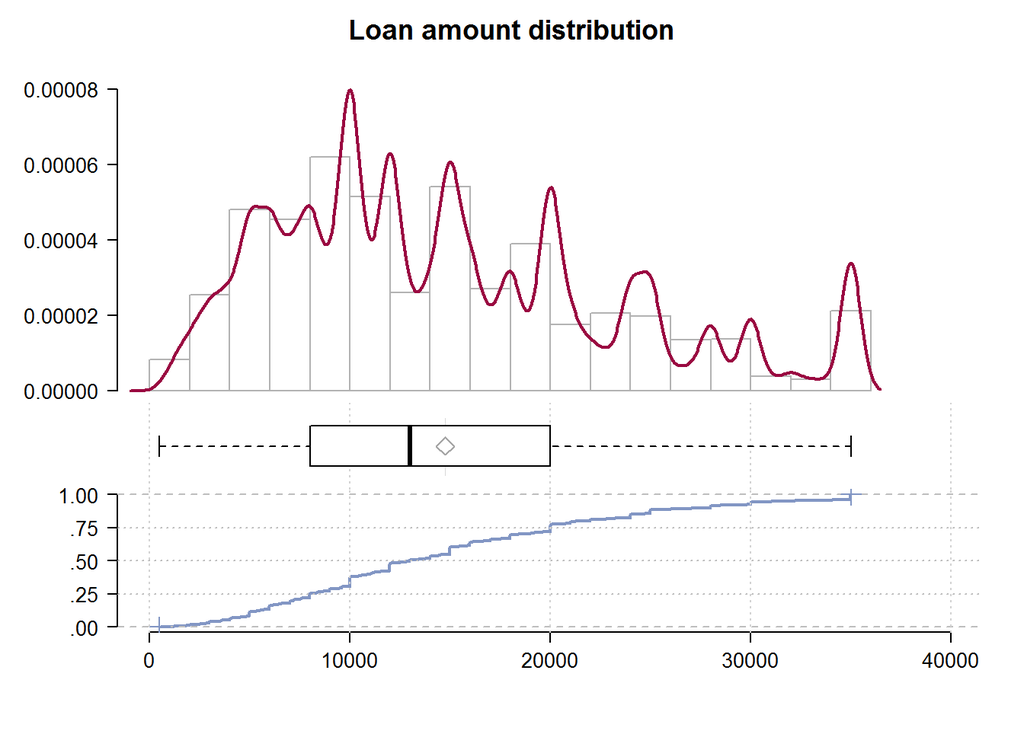

```r
Desc(loanbook$loan_amnt, main="Loan amount distribution", plotit=TRUE)
```

Here is how the loan book was growing:

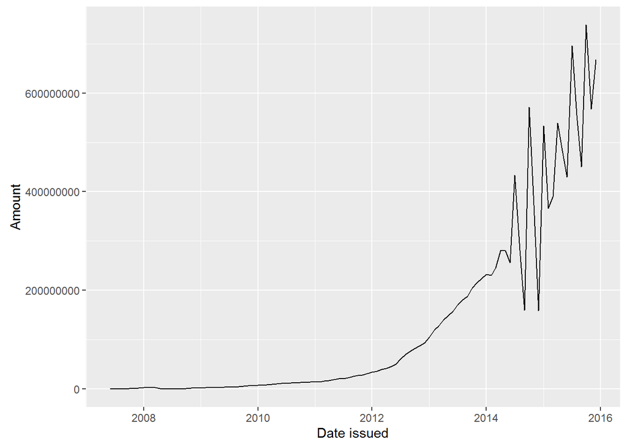

```r
loanbook$issue_d <-as.Date(gsub("^","01-",loanbook$issue_d), format="%d-%b-%Y")

amnt_df <- loanbook %>% #Learn from it
  select(issue_d, loan_amnt) %>%
  group_by(issue_d) %>%
  summarise(Amount= sum(loan_amnt))

ts_amnt <- ggplot(amnt_df, aes(x= issue_d, y=Amount))

ts_amnt + geom_line() + xlab("Date issued")
```

## Loan statues

Terms interpretation:

Charged off: Loan for which there is no longer a reasonable expectation of further payments. Generally, Charge Off occurs no later than 30 days after the Default status is reached. Upon Charge Off, the remaining principal balance of the Note is deducted from the account balance. Charge Off typically occurs when a loan is 150 days past due (i.e. 30 days after the Default status is reached) and there is no reasonable expectation of sufficient payment to prevent the charge off.

Default: Loan has not been current for 121 days or more. The loanbook consists of loans in various statuses so I started with exploring their frequency. In general, a Note enters Default status when it is 121+ days past due.

In Grace Period: Loan is past due but within the 15-day grace period.

Current: Loan is up to date on all outstanding payments.

```
## -------------------------------------------------------------------------
## loanbook$loan_status (character)
##
##    length       n     NAs  unique  levels   dupes
##   887'379 887'379       0      10      10       y
##
##                                                   level     freq   perc  cumfreq  cumperc
## 1                                               Current  601'779  67.8%  601'779    67.8%
## 2                                            Fully Paid  207'723  23.4%  809'502    91.2%
## 3                                           Charged Off   45'248   5.1%  854'750    96.3%
## 4                                    Late (31-120 days)   11'591   1.3%  866'341    97.6%
## 5                                                Issued    8'460   1.0%  874'801    98.6%
## 6                                       In Grace Period    6'253   0.7%  881'054    99.3%
## 7                                     Late (16-30 days)    2'357   0.3%  883'411    99.6%
## 8    Does not meet the credit policy. Status:Fully Paid    1'988   0.2%  885'399    99.8%
## 9                                               Default    1'219   0.1%  886'618    99.9%
## 10  Does not meet the credit policy. Status:Charged Off      761   0.1%  887'379   100.0%
```

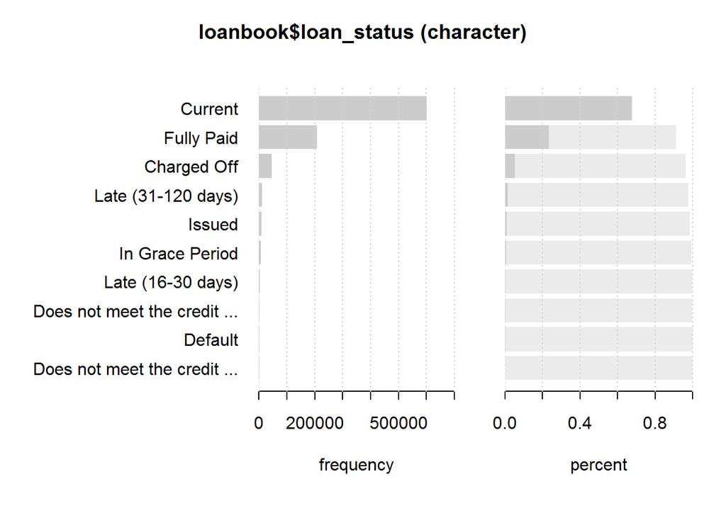

```r
Desc(loanbook$loan_status, plotit=TRUE) #categorical variable, same code with different plot
```

Then I checked the distribution of loan amounts by status.

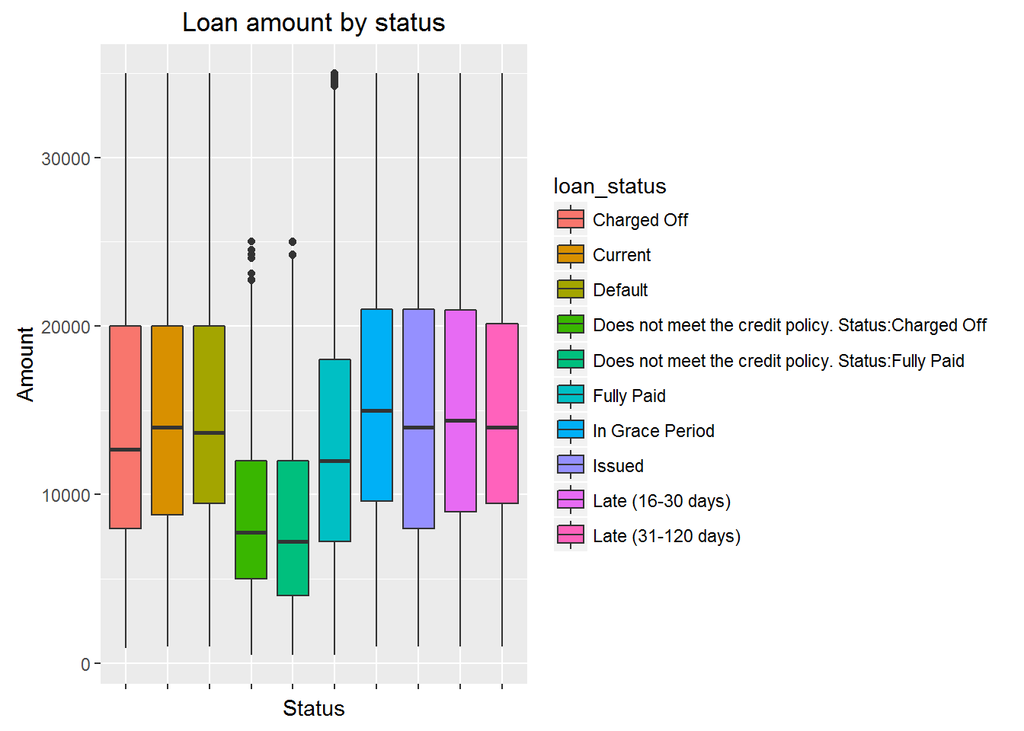

```r
box_status <- ggplot(loanbook, aes(loan_status, loan_amnt))
box_status + geom_boxplot(aes(fill=loan_status)) +
  theme(axis.text.x= element_blank()) +
  labs(list(
    title= "Loan amount by status",
    x= "Status",
    y="Amount"))
```

```r
# box_status gives basic outline of the plot. Namely x axis and y axis
# geom_boxplot(aes(fill=loan_status)) filled the boxplot
# theme(axis.text.x= element_blank()) eliminate axis.text.x
# labs(list(title= "Loan amount by status", x= "Status", y="Amount")) given titles
```

Here is how the value of loans of different grades was changing over time

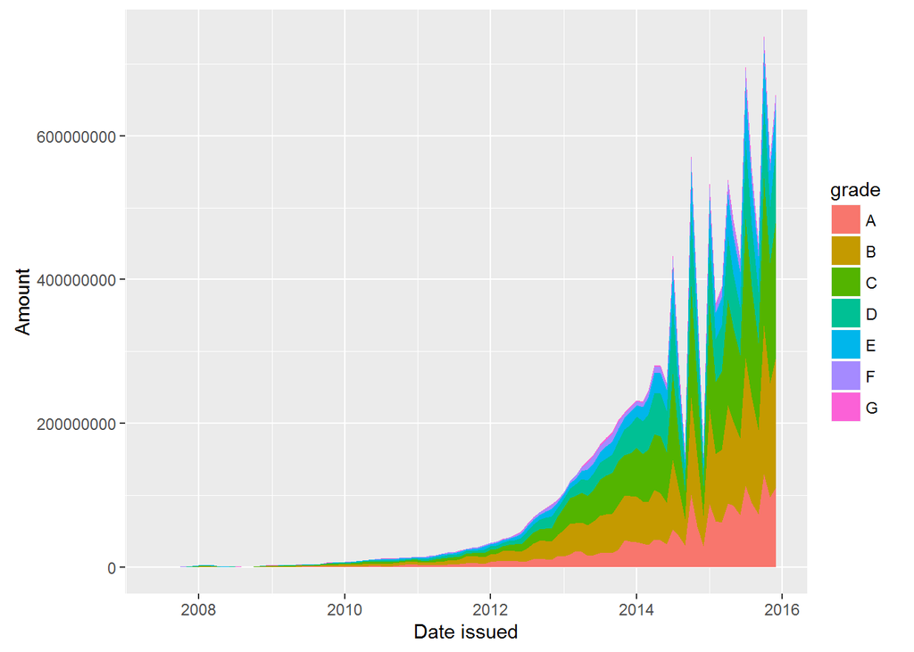

```r
amnt_df_grade <- loanbook %>%
  select(issue_d, loan_amnt, grade) %>%
  group_by(issue_d, grade ) %>%
  summarise(Amount= sum(loan_amnt))

ts_amnt_grade <- ggplot(amnt_df_grade,
                        aes(x= issue_d, y= Amount))

ts_amnt_grade + geom_area(aes(fill= grade)) +xlab("Date issued")
```

## Maps

In oder to create maps of loans the author initially joined the loan book with names of states and then the author createda data frame required by choroplethr.

### Loans by value

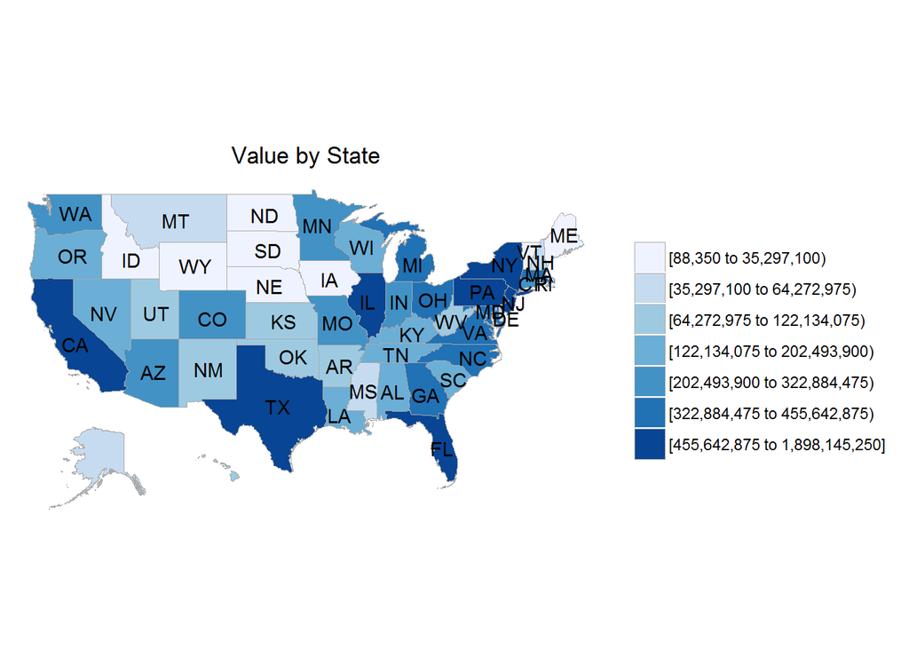

```r
state_by_value <-
  loanbook %>% group_by(region) %>%
  summarise(value= sum(loan_amnt, na.rm= TRUE))

state_choropleth(state_by_value, title = "Value by State")
```

### Loans by volume

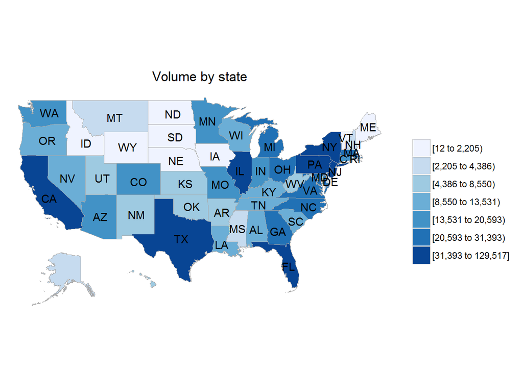

```r
state_by_volume <-
  loanbook %>%
  group_by(region) %>%
  summarise(value=n())

state_choropleth(state_by_volume, title= "Volume by state")
```

### What’s the reason for taking a loan with LengingClub?

```
## -------------------------------------------------------------------------
## Loan purposes
##
##    length       n     NAs  unique  levels   dupes
##   887'379 887'379       0      14      14       y
##
##                  level     freq   perc  cumfreq  cumperc
## 1   debt_consolidation  524'215  59.1%  524'215    59.1%
## 2          credit_card  206'182  23.2%  730'397    82.3%
## 3     home_improvement   51'829   5.8%  782'226    88.2%
## 4                other   42'894   4.8%  825'120    93.0%
## 5       major_purchase   17'277   1.9%  842'397    94.9%
## 6       small_business   10'377   1.2%  852'774    96.1%
## 7                  car    8'863   1.0%  861'637    97.1%
## 8              medical    8'540   1.0%  870'177    98.1%
## 9               moving    5'414   0.6%  875'591    98.7%
## 10            vacation    4'736   0.5%  880'327    99.2%
## 11               house    3'707   0.4%  884'034    99.6%
## 12             wedding    2'347   0.3%  886'381    99.9%
## ... etc.
##  [list output truncated]
```

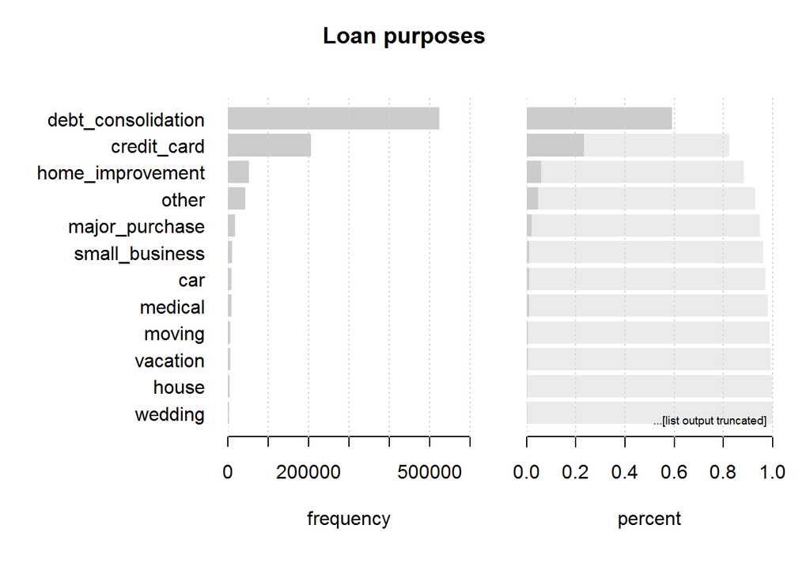

```r
Desc(loanbook$purpose, main= "Loan purposes", plotit= TRUE)
```

```
## -------------------------------------------------------------------------
## Loan titles
##
##    length       n     NAs  unique  levels   dupes
##   887'379 887'228     151  61'452  61'452       y
##
##                       level     freq   perc  cumfreq  cumperc
## 1        Debt consolidation  414'352  46.7%  414'352    46.7%
## 2   Credit card refinancing  164'341  18.5%  578'693    65.2%
## 3          Home improvement   40'170   4.5%  618'863    69.8%
## 4                     Other   31'892   3.6%  650'755    73.3%
## 5        Debt Consolidation   16'414   1.9%  667'169    75.2%
## 6            Major purchase   12'051   1.4%  679'220    76.6%
## 7                  Business    6'746   0.8%  685'966    77.3%
## 8          Medical expenses    6'675   0.8%  692'641    78.1%
## 9             Consolidation    5'675   0.6%  698'316    78.7%
## 10            Car financing    5'565   0.6%  703'881    79.3%
## 11       debt consolidation    5'082   0.6%  708'963    79.9%
## 12    Moving and relocation    3'921   0.4%  712'884    80.3%
## ... etc.
##  [list output truncated]
```

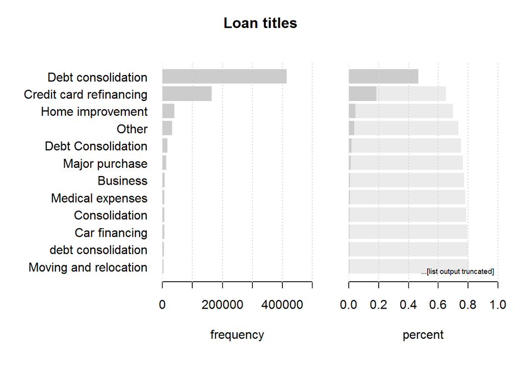

```r
Desc(loanbook$title, main= "Loan titles", plotit= TRUE)
```

## Word cloud

Word cloud gives a good overview of the loan titles (gives by borrowers). This information should explain what kind of loans are bing funded by LendingClub.

In order to create a word cloud, First the author loaded the necessary libraries, then he preprocessed the ‘title’ column by removing punctuation and transforming it to lower case. This analysis was run on the first 10000 rows to speed up the process.

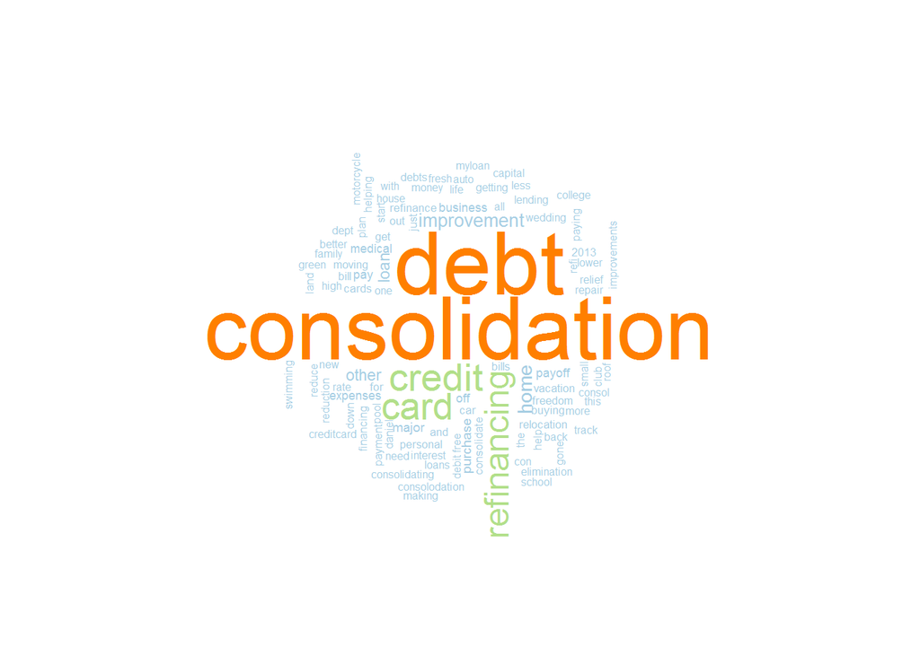

```r
library(tm)
library(RColorBrewer)
library(wordcloud)

loan_descriptions.corpus <- Corpus(DataframeSource(data.frame(head(loanbook[,23],n=10000))))
loan_descriptions.corpus <- tm_map(loan_descriptions.corpus, removePunctuation)
loan_descriptions.corpus <- tm_map(loan_descriptions.corpus, content_transformer(tolower))

wordcloud(loan_descriptions.corpus,
          max.words = 100,
          random.order= FALSE, #plotted in decreasing frequency
          rot.per = 0.30, #proportion words with 90 degree rotation
          use.r.layout = FALSE, #C++ code is used for collision detection
          colors = brewer.pal(8, "Paired"))
```

## Loan grades

Here is the overview of the occurrence of loans of different grades:

```
## -------------------------------------------------------------------------
## Loan grades
##
##    length       n     NAs  unique  levels   dupes
##   887'379 887'379       0       7       7       y
##
##    level     freq   perc  cumfreq  cumperc
## 1      B  254'535  28.7%  254'535    28.7%
## 2      C  245'860  27.7%  500'395    56.4%
## 3      A  148'202  16.7%  648'597    73.1%
## 4      D  139'542  15.7%  788'139    88.8%
## 5      E   70'705   8.0%  858'844    96.8%
## 6      F   23'046   2.6%  881'890    99.4%
## 7      G    5'489   0.6%  887'379   100.0%
```

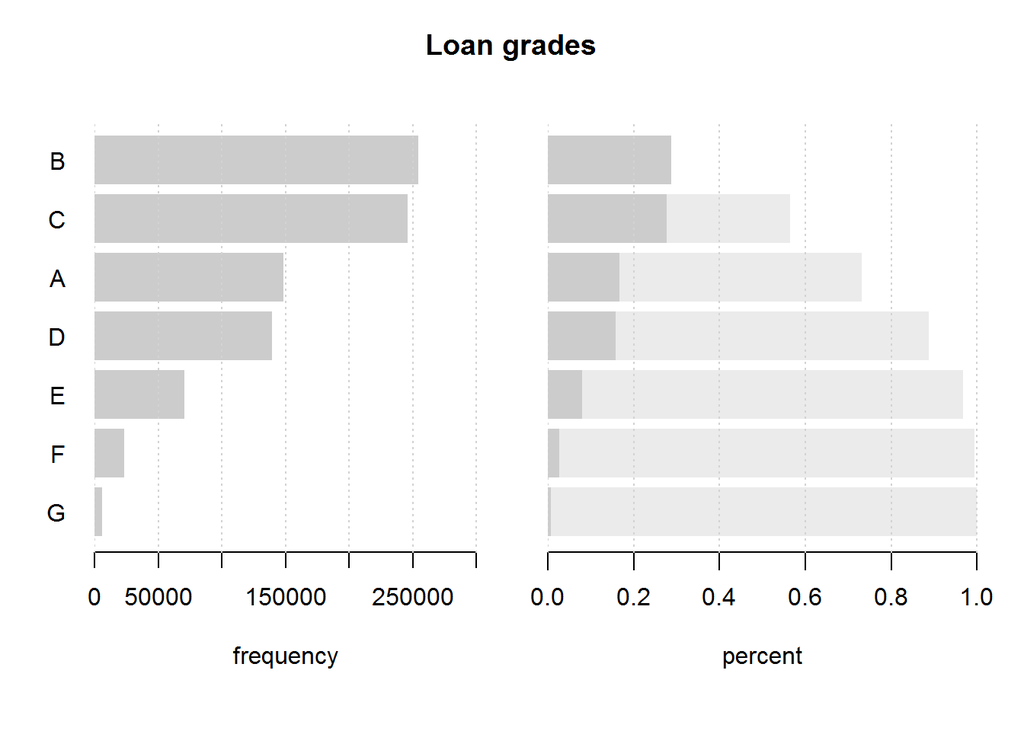

```r
Desc(loanbook$grade, main= "Loan grades", plotit=TRUE)
```

The last step (so far) was checking whether the interest rates are dependent on the loan grade.

```
## -------------------------------------------------------------------------
## Interest rate by grade
##
## Summary:
## n pairs: 887'379, valid: 887'379 (100.0%), missings: 0 (0.0%), groups: 7
##
##
##               A        B        C        D        E        F        G
## mean        7.2     10.8     14.0     17.2     19.9     23.6     25.6
## median      7.3     11.0     14.0     17.0     20.0     23.8     25.8
## sd          1.0      1.4      1.2      1.2      1.5      1.5      2.0
## IQR         1.4      2.1      1.7      1.6      2.4      1.5      0.3
## n       148'202  254'535  245'860  139'542   70'705   23'046    5'489
## np        16.7%    28.7%    27.7%    15.7%     8.0%     2.6%     0.6%
## NAs           0        0        0        0        0        0        0
## 0s            0        0        0        0        0        0        0
##
## Kruskal-Wallis rank sum test:
##   Kruskal-Wallis chi-squared = 805190, df = 6, p-value < 0.00000000000000022
```

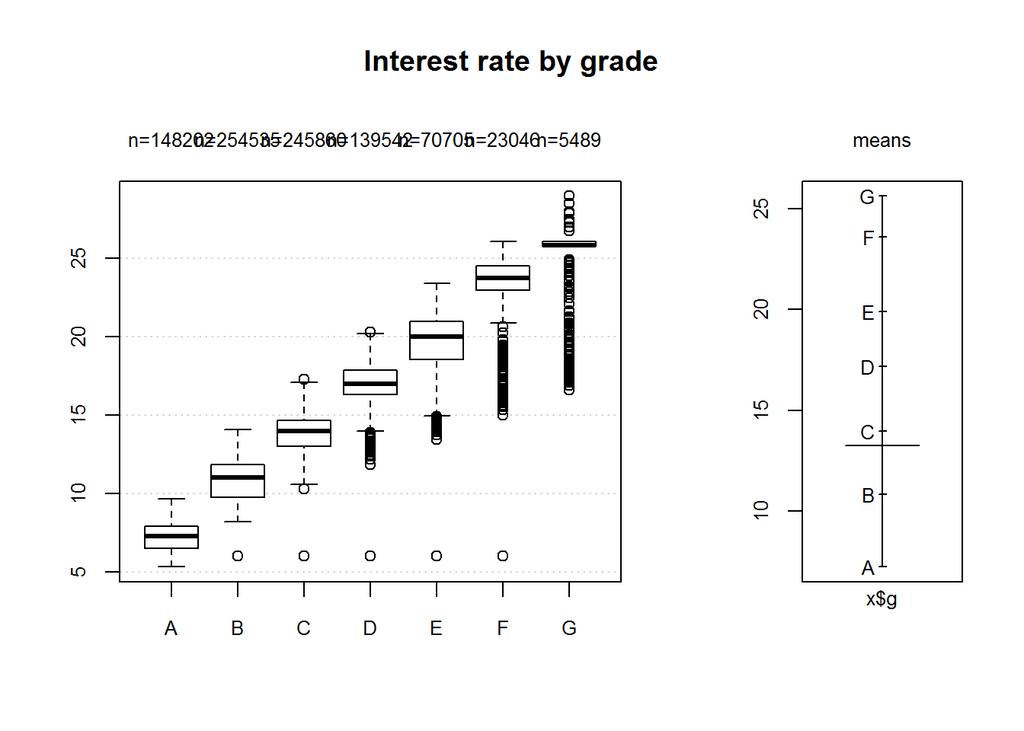

```r
Desc(int_rate~grade, loanbook, digits= 1, main= "Interest rate by grade", plotit= TRUE)
```

Unsurprisingly, the higher the grade (more risky loan), the higher the interest rates.

## Default prediction

There are several statuses which indicate that loans are not perfroming well. The author put them into two groups.

```r
#'bad' statuses
bad_indicators <- c("Charged off",
                    "Default",
                    "Does not meet the credit policy. Status:Charged Off",
                    "In Grace Period",
                    "Default Receiver",
                     "Late (16-30 days)",
                      "Late (31-120 days)")

# assign certain statuses to a 'bad' ('0') group
loanbook$is_bad <- ifelse(loanbook$loan_status %in% bad_indicators, 0,                                           ifelse(loanbook$loan_status=="", NA, 1)
                          )
```

Then the author checks wheher there is a difference between the ‘bad’ abd ‘good’ loans for numeric variables.

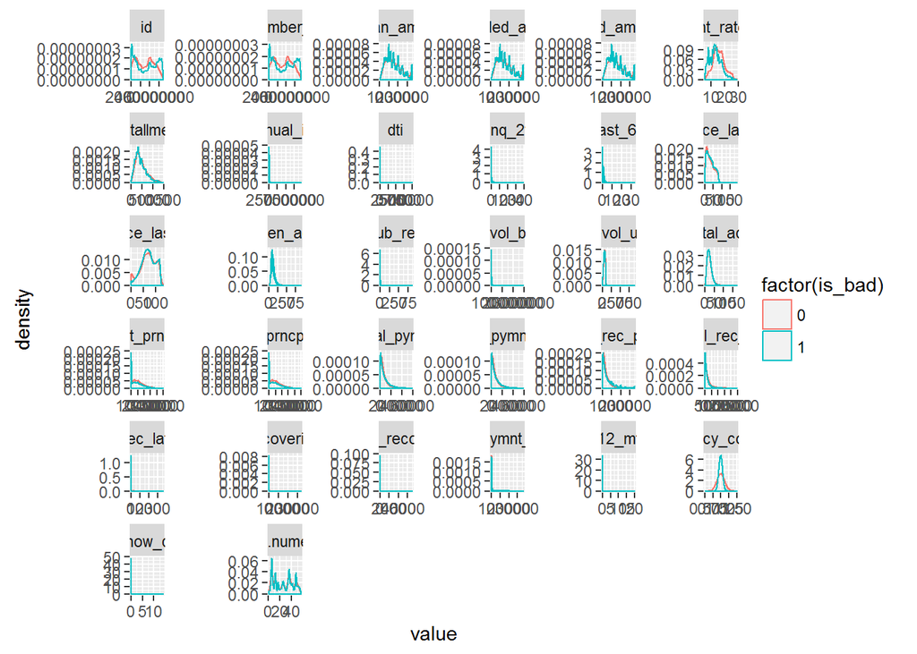

```r
#figure out which columns are numeric so that we can look at the distribution
numeric_cols <- sapply(loanbook, is.numeric)

# turn the data into long format
library(reshape2)
loanbook.lng <- melt(loanbook[,numeric_cols], id="is_bad")

#plot the distribution for 'bad' and 'good' for each numeric variable
p <- ggplot(aes(x= value, group= is_bad, colour= factor(is_bad)),
            data= loanbook.lng)

#create the plot to check if there are any good variables that can be used in predictive models
p + geom_density() +
  facet_wrap(~variable, scales="free")
```

The plot above can be the basis for chosing variables for predictive models (note: scales need fixing).

It seems like Annual Income and Interest Rate are two variables that can be good predictors of how loans will behave We can have a closer look at particular cases:

```r
library(DT)

loanbook %>%
  filter(is_bad=='0') %>%
  select(annual_inc, int_rate, loan_status) %>%
  datatable(., options= list(pageLength= 10))
```

|  | annual_inc | int_rate | loan_status |
| --- | --- | --- | --- |
| 1 | 200000 | 13.66 | Late (31-120 days) |
| 2 | 65000 | 15.22 | Late (31-120 days) |
| 3 | 14200 | 12.69 | In Grace Period |
| 4 | 37000 | 16.99 | Late (31-120 days) |
| 5 | 110000 | 11.67 | Late (16-30 days) |
| 6 | 42000 | 18.24 | In Grace Period |
| 7 | 60000 | 17.57 | Late (31-120 days) |
| 8 | 38608 | 18.55 | Late (31-120 days) |
| 9 | 78000 | 12.69 | Late (31-120 days) |
| 10 | 15336 | 16.29 | In Grace Period |

[output cut: 22171 more lines]